# rco-optimization-example-by-Rahul Saxena

Rahul Saxena

21/03/2020

## Problem Statement:

Write a chunk of code that would result automatically optimized by applying the **rco::optimize_files** function, and compare its execution time (with *microbenchmark::microbenchmark*) against the non-optimized code. This should be submited as a vignette named *“rco-optimization-example-by-STUDENT.Rmd”.*

Since the chunk of code was not specified, I went ahead with the code example provided at https://github.com/jcrodriguez1989/rco/ and used the *rco::optimize_files* function and *microbenchmark::microbenchmark* function on it.

Below is the code, I originally had and the optimized code that I recieved as a result of using the *rco::optimize_files* function.

## Original Code:

```r
og_code <- function()
{
  over_million <- 1
  years_old <- 29
  days_old <- 365 * years_old # leap years don't exist",
  hours_old <- 24 * days_old
  seconds_old <- 60 * 60 * hours_old
  if (seconds_old > 10e6) {
    over_million <- over_million + 1
  } else {
    over_million <- over_million - 1
  }
}
```

## Optimized Code {6 Number of Optimizations}

The result is obtained in a file called *optimizes_filename.R* in the working directory, after the application of *rco::optimize_files(“filename.R”)*.

```r
opt_code <- function()
{
# leap years don't exist",
2
}
```

## Benchmarkings:

Benchmarking the optimized and original functions, we get the following values:

```r
library("microbenchmark")
microbenchmark(og_code(), opt_code(), times = 1000L)
```

```
## Unit: nanoseconds
##        expr min  lq    mean median   uq     max neval
##   og_code() 400 600 10205.2   1200 1400 8893900  1000
##  opt_code() 100 200  1930.5    300  400 1537800  1000
```

## Plots:

Comparing the benchmark plots of the original function and the optimized function using the ggplot2::autoplot() function, we get the following

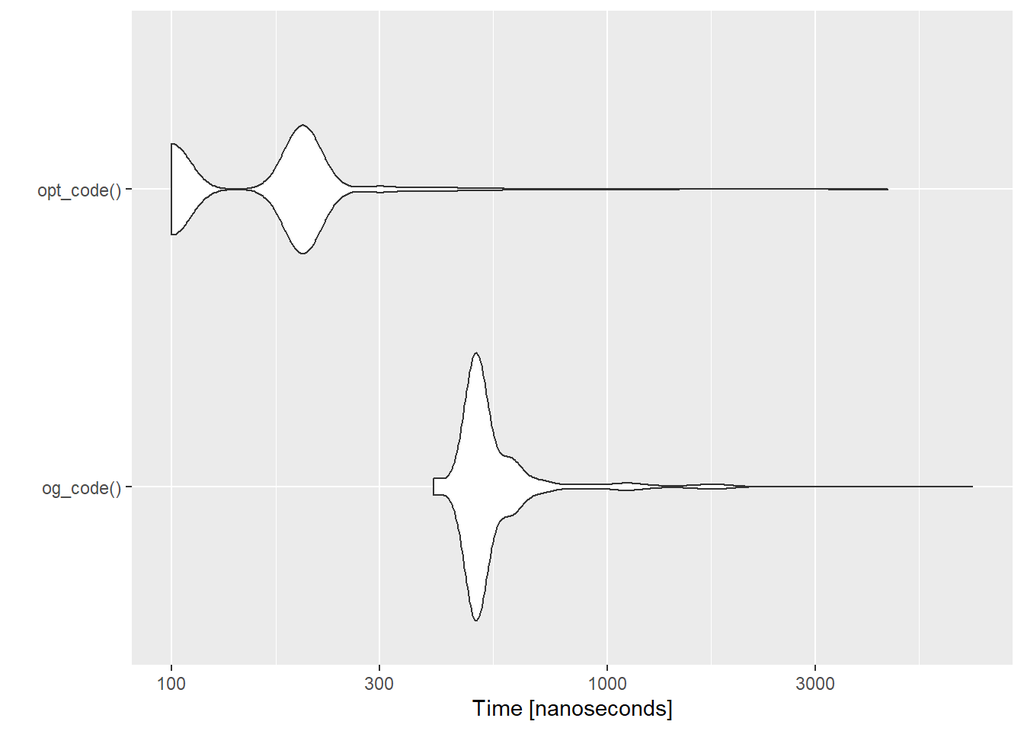

```r
library("microbenchmark")
library("ggplot2")
autoplot(microbenchmark(og_code(), opt_code(), times = 1000L))
```

## Observations:

I took a function called og_code() and optimized it using the rco::optimize_files() and it generated a function called opt_code(). It is a pretty impressive optimization, to say the least, because first it incorporates the constant propogation optimization and then proceeds to incorporate dead expression elimination.

This optimization is reflected in the benchmarks of the two functions. On an average, the timings for the functions were (in nanoseconds):

[output not shown]